[figure not shown]

[figure not shown]

[figure not shown]

# **Informe de resultados NOCTUA+ 2025**

## **Información sobre el punto**

V1

Punto de muestreo

Laguna_Velilla_Cortado

Voluntario/a

Iván Fernández Clemente

Temporada

Localización

Madrid (40.35911, -3.5052)

Hábitat *

[figure not shown]

D

30

1

2

[interactive chart not shown]

* Ver [ficha de hábitats de SEO/BirdLife](https://seo.org/wp-content/uploads/2012/04/habitats_seo4.pdf)

## **Información sobre la grabadora**

[output not shown]

Configuración:

| Régimen de grabación | Desde 1 h antes del atardecer* hasta 2 h después: 1 minuto de cada 3 (60 minutos por noche) |
| --- | --- |
| Ganancia | Med |
| Frecuencia de muestreo | 32 kHz |
| Periodo de grabación en el punto | 2025-02-23 - 2025-06-22 |

Instalación:

| Fecha de instalación | 2025-02-22 |
| --- | --- |
| Fecha de retirada | 2025-06-22 |
| Altura | 3 m |
| Microhábitat | Tronco |

## **Comunidad de aves nocturnas**

En tu punto de muestreo han vocalizado **4 especies**

- Autillo europeo (*Otus scops*)
- Mochuelo europeo (*Athene noctua*)
- Lechuza común (*Tyto alba*)
- Búho chico (*Asio otus*)

### **¿Cuántas noches ha cantado cada especie?**

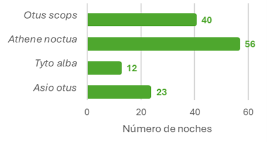

El **mochuelo común** es el ave que ha cantado más número de noches.

### **¿Cuántas veces por noche ha cantado cada especie?**

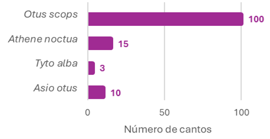

El **autillo europeo** es el ave que más ha cantado cada noche, de media.

### **¿Cuánto tiempo ha cantado en total cada especie?**

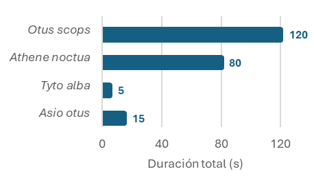

El **autillo europeo** es la especie qué más actividad acústica ha tenido.

## **Fenología - ¿Cuándo han cantado las aves nocturnas?**

### **Durante la temporada**

[figure not shown]

### **Durante la noche**

[figure not shown]

(gráfico: media del primer y último minuto respecto al atardecer en el que hay vocalizaciones de cada especie)

## **Ejemplos de grabaciones**

### **Especies**

[interactive chart not shown]

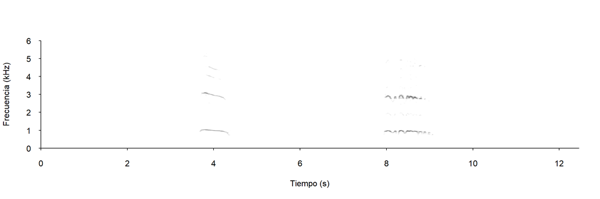

## **Más información**

Para ver los resultados globales del programa **NOCTUA con grabadoras** visita la web [Noctua+](https://inesdiazg.github.io/noctua-mas/resultados).

Para más información sobre el **programa NOCTUA** visita la [web de SEO/BirdLife](https://seo.org/noctua-4/).

#### Contacto:

noctua@seo.org

91 434 09 10